# Wrangle_datasets

2024-05-08

# Setup

```r
library(tidyverse)
library(lubridate)
library(ggthemes)
library(assertthat)
library(langcog) # for CIs
library(mirt)
library(ggpubr)
library(knitr)
library(dplyr)
library(here)
library(lme4)
library(lmerTest)
library(digest)
library(viridis)
```

## Load data from multiafc task

First load all metadata we’ll need for the items

```r
test_corpus <- read_csv(here::here("data/item_metadata/test_items.csv")) %>%
  filter(!Word1 %in% c('honey','scrabble')) # manually excluded
```

# New merged data post preprcoessing

```r
multiafc_combined <- read_csv(here::here("data/raw/multiAFC_4AFC_clean_combined_data_20251203.csv")) %>%
  mutate(bing = str_detect(pid, 'bing')) %>%
  filter(bing==FALSE) %>% # will merge in later manually
  mutate(cohort='schools')
```

# Load metadata

## examine items across aoa bins

```r
clip_cor_by_model <- read_csv(here::here("data/raw/exp1_all_trials2023-04-11.csv")) %>%
  select(Word1, Word2, trial_type, cor, AoA_Est_Word2, AoA_Est_Word1) %>%
  rename(wordPairing = trial_type) %>%
  rename(clip_cor = cor) %>%
  filter(Word1 %in% unique(test_corpus$Word1))  %>%
  filter(!Word1 %in% c('honey','scrabble')) %>% # manually excluded for symmetry across blocks
  ungroup() %>%
  mutate(AoA_Bin = ntile(AoA_Est_Word1,3)) %>%
  mutate(AoA_Bin_Name = factor(AoA_Bin,  levels = c('1','2','3'), labels = c("Early AoA", "Med AoA", "Late AOA")))
```

```r
sanity <- clip_cor_by_model %>%
  group_by(AoA_Bin_Name) %>%
  summarize(num_words = length(unique(Word1)), meanAoA = mean(AoA_Est_Word1))
```

# Load data

Load data and restrict to clip words (no dutch)

```r
test_clip_cor <- read_csv(here::here("data/raw/exp1_all_trials2023-04-11.csv")) %>%
  select(Word1, Word2, trial_type, cor, AoA_Est_Word2, AoA_Est_Word1) %>%
  rename(wordPairing = trial_type) %>%
  rename(clip_cor = cor) %>%
  filter(Word1 %in% unique(test_corpus$Word1)) %>%
  filter(!Word1 %in% c('honey','scrabble')) # manually excluded for symmetry across blocks
```

Create data structure and merge that has clip cor==1 for target selection

```r
test_clip_cor_identity <- test_clip_cor %>%
  select(Word1, AoA_Est_Word1) %>%
  distinct(Word1, AoA_Est_Word1) %>%
  mutate(Word2 = Word1) %>%
  mutate(AoA_Est_Word2 = AoA_Est_Word1) %>%
  mutate(clip_cor = 1) %>%
  mutate(wordPairing = 'target')

test_clip_cor <- test_clip_cor %>%
  full_join(test_clip_cor_identity) %>%
  arrange(Word1)
```

Rename meta data structures so that they merge correctly with trial data

```r
clip_to_join <- test_clip_cor %>%
  rename(targetWord = Word1) %>%
  rename(answerWord = Word2)
```

```r
test_corpus <- test_corpus %>%
  left_join(test_clip_cor)

sum(is.na(test_corpus$clip_cor))
```

```
## [1] 0
```

## Read in bing & garden data

```r
bing = read_csv(here::here('data/raw/all_bing_data_for_item_info.csv'))  %>%
  mutate(age_group = as.numeric(floor(age_in_months/12))) %>%
  select(-block) %>%
  mutate(cohort='bing')
```

```r
garden = read_csv(here::here('data/raw/all_garden_roar_data_with_age.csv'))   %>%
  mutate(start_time = as.character(start_time)) %>%
  filter(assessment_stage=='test_response')  %>%
  select(-assessment_stage) %>%
  mutate(age_group = floor(age_in_years))  %>%
  select(pid, targetWord, answerWord, correct, rt, numAFC, age_in_years, age_group) %>%
  mutate(cohort='garden')
```

## Read in multi-afc adult data

Set age to “25” so we can plot it together

```r
adults <- read_csv(here::here("data/raw/multi-afc-april28.csv"))  %>%
  mutate(age_group = as.numeric(25)) %>% # set
  filter(task == 'test_response') %>%
  select(pid, targetWord, answerWord, correct, rt, numAFC, age_group) %>%
    mutate(cohort='adults')
```

```r
manual_pids <- garden %>%
  select(pid) %>%
  full_join(adults %>% select(pid)) %>%
  full_join(bing %>% select(pid)) %>%
  distinct()
```

## Make trial-levels data structure across all ages

```r
trial_data <- multiafc_combined %>%
  mutate(age_group = floor(ageMonths/12)) %>%
  filter(age_group<15) %>%
  filter(group!='B') %>% # garden participants, will merge manually
  filter(!pid %in% manual_pids$pid) %>%
  full_join(garden) %>% # manually merge garden instead for age/pid difficulties
  full_join(adults)  %>%
  full_join(bing) %>%
  filter(targetWord %in% clip_to_join$targetWord) %>%
  left_join(clip_to_join)
```

```r
missing = trial_data %>% filter(is.na(age_group))

length(unique(missing$pid))
```

```
## [1] 0
```

## Parse out item-level responses

Join together and clean datastructures

```r
df.multiAFC.trials <- trial_data %>%
  left_join(test_corpus %>% rename(targetWord = "Word1", answerWord = "Word2")) %>%
  filter(is.na(itemGroup) | (itemGroup == "test")) %>%
  mutate(wordPairing = ifelse(is.na(wordPairing), "target", wordPairing)) %>%
  filter(!targetWord %in%  c("ant","ball","bear","scrabble","honey")) %>%
  select(pid, answerWord, targetWord, numAFC, correct, rt, wordPairing, age_group, clip_cor,cohort)

df.4AFC.trials <- df.multiAFC.trials %>%
  filter(numAFC==4)

rm(df.multiAFC.trials) # force 4afc from now on
```

# Now get rid of weird participants

# Get rid of people who are at chance

```r
at_chance <- df.4AFC.trials %>%
  group_by(age_group, pid) %>%
  summarize(pc = mean(correct), num_trials = length(unique(targetWord)))  %>%
  filter(age_group>6) %>%
  filter(pc<.3)
```

```r
df.4AFC.trials.clean <- df.4AFC.trials %>%
  # filter(!pid %in% at_chance$pid) %>%
  filter(age_group>0) # 1 weird participant with no metadata
```

Create age/group and number of participants for filtering for plots / age-based analyses

```r
age_group_pid <- df.4AFC.trials.clean %>%
  group_by(age_group) %>%
  summarize(num_pids = length(unique(pid)))
```

## Create intermediate data structures

Now write code to fill out response pattern for all possible target/distractor responses on each age for each age…for use later.

```r
full_item_structure_4AFC <- clip_to_join %>%
  mutate(numAFC = 4)
```

Now fill this out by all ages in the dataset, oof this was annoying

```r
full_item_structure_by_age_4afc = map_df(age_group_pid$age_group, ~full_item_structure_4AFC %>% mutate(age_group = .x))
```

## Calculate proportion of times participants chose an image

First do this across all age groups – for basic item plots.

```r
df.4AFC.totalAttempts <- df.4AFC.trials.clean %>%
  group_by(targetWord, numAFC) %>%
  tally() %>%
  dplyr::rename(totalAttempts = n)

# this includes target word selection
df.4AFC.distractor.summary <- df.4AFC.trials.clean %>%
  group_by(targetWord,  answerWord, wordPairing) %>%
  tally() %>%
  left_join(df.4AFC.totalAttempts) %>%
  mutate(perc = n/totalAttempts) %>%
  full_join(full_item_structure_4AFC) %>% # need to fill out item structure (but not by age)
  mutate(perc = replace_na(perc, replace=0))
```

Look at histogram of how often an item was attempted overal

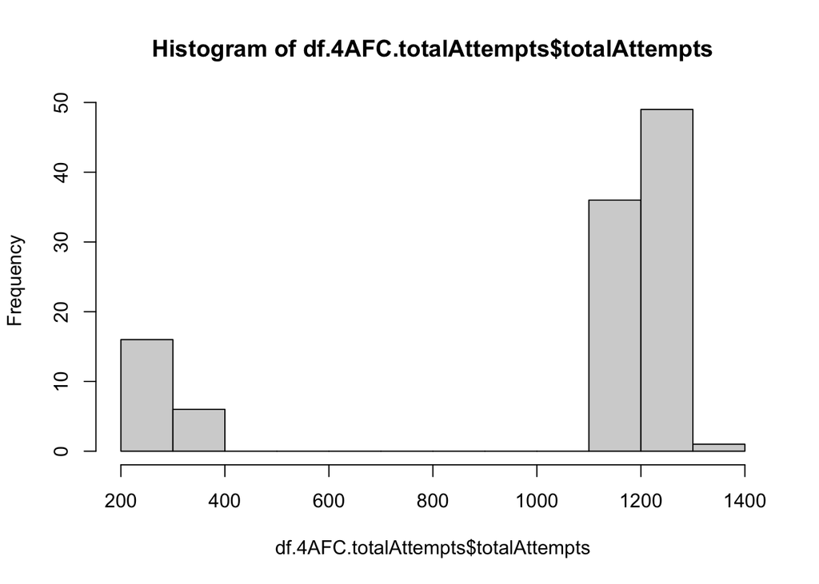

```r
hist(df.4AFC.totalAttempts$totalAttempts)
```

Look at histograms of how often the target was chosen

```r
target_pc <- df.4AFC.distractor.summary %>%
  filter(wordPairing=='target') %>%
  arrange(perc)

# hist(target_pc$perc)
```

# Construct response dataframe now by age group

```r
df.4AFC.totalAttempts.byAge <- df.4AFC.trials.clean %>%
  group_by(targetWord, age_group) %>%
  tally() %>%
  dplyr::rename(totalAttempts = n)

df.4AFC.distractor.summary.byAge <- df.4AFC.trials.clean %>%
  group_by(targetWord,  answerWord, wordPairing, age_group) %>%
  summarise(n = n(), medianRT = median(rt)) %>%
  left_join(df.4AFC.totalAttempts.byAge) %>%
  mutate(perc = n/totalAttempts) %>%
  full_join(full_item_structure_by_age_4afc)
```

```r
what <- df.4AFC.distractor.summary.byAge %>%
  filter(is.na(perc))
```

There are some missing observations because these items were never even SEEN – these are true NAs and mostly concentrated in the youngest kids

```r
unseen_target_items_by_age_group <- df.4AFC.totalAttempts.byAge %>%
  full_join(full_item_structure_by_age_4afc %>% distinct(targetWord, age_group)) %>%
  filter(is.na(totalAttempts))
```

couple of sanity checks for missing values that shuold be zero

```r
assert_that(sum(is.na(df.4AFC.distractor.summary.byAge$age_group))==0)
```

```
## [1] TRUE
```

```r
assert_that(sum(is.na(df.4AFC.distractor.summary.byAge$clip_cor))==0)
```

```
## [1] TRUE
```

There are some missing observations because these items were never chosen on a given trial/age group – need to fill those out

But we also have some target/distractor/age group pairings that are VERY sparsely populated – that makes sense especially as kids get more accurate and don’t choose distal items. We also have relatively few younger kids.

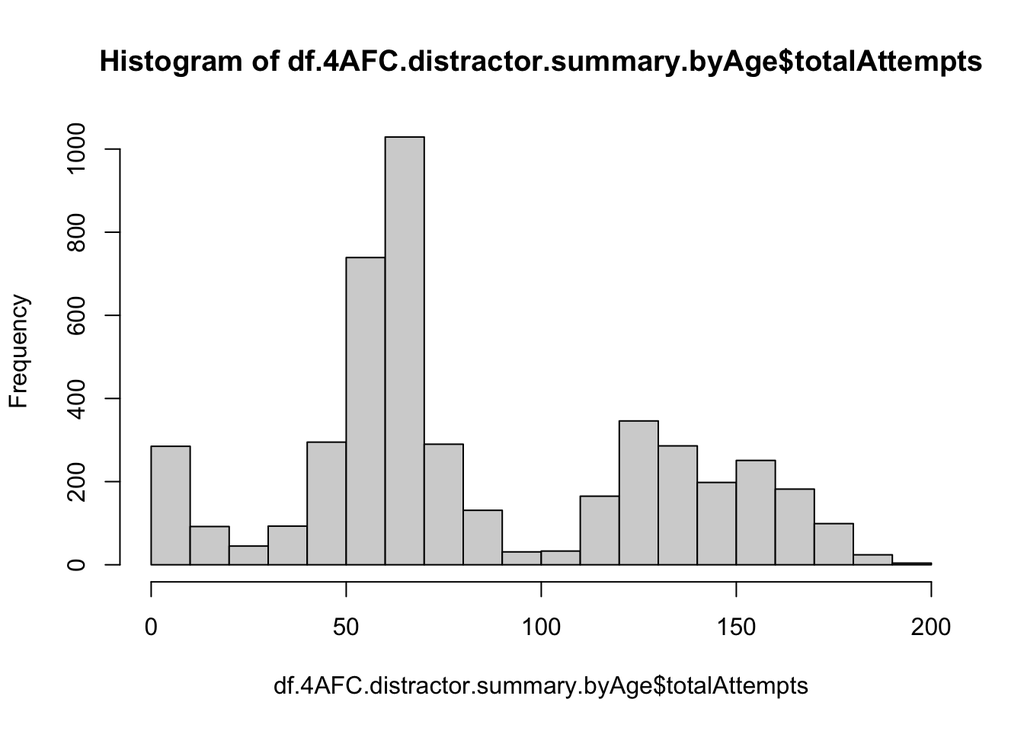

```r
hist(df.4AFC.distractor.summary.byAge$totalAttempts)
```

## These are true NAs because never seen

```r
unseen_items <- df.4AFC.distractor.summary.byAge  %>%
  right_join(unseen_target_items_by_age_group)
```

But we now need to populate “0” value in the percent chosen category for distractor items that were never chosen and so not in the data structure

OK, put it back all together

```r
df.4AFC.distractor.summary.byAge.clean <- df.4AFC.distractor.summary.byAge %>%
  anti_join(unseen_items) %>% # get rid of unseen items
  mutate(perc = replace_na(perc, replace=0)) %>% # now replace non-chosen with 0
  full_join(unseen_items) %>% # rejoin these  true NAs
  ungroup() %>%
  mutate(AoA_Bin = ntile(AoA_Est_Word1,3)) %>%
  mutate(AoA_Bin_Name = factor(AoA_Bin,  levels = c('1','2','3'), labels = c("Early AoA", "Med AoA", "Late AOA")))
```

Make sure we have it all filled out correctly

```r
sanity_check <- df.4AFC.distractor.summary.byAge.clean %>%
  filter(numAFC==4) %>%
  group_by(age_group, targetWord) %>%
  summarize(count = n())

assert_that(sum(sanity_check$count!=4)==0) #
```

```
## [1] TRUE
```

```r
df.4AFC.distractor.summary.byAge.clean
```

```
## # A tibble: 5,616 × 14
##    targetWord answerWord wordPairing age_group     n medianRT totalAttempts
##    <chr>      <chr>      <chr>           <dbl> <int>    <dbl>         <int>
##  1 acorn      acorn      target              3    45    3931             59
##  2 acorn      acorn      target              4    57    3117             62
##  3 acorn      acorn      target              5    68    3130.            70
##  4 acorn      acorn      target              6    62    2428.            66
##  5 acorn      acorn      target              7    56    1888             58
##  6 acorn      acorn      target              8   141    1941            148
##  7 acorn      acorn      target              9   145    1864            158
##  8 acorn      acorn      target             10    98    1688            102
##  9 acorn      acorn      target             11   128    1600            131
## 10 acorn      acorn      target             12   137    1579            142
## # ℹ 5,606 more rows
## # ℹ 7 more variables: perc <dbl>, clip_cor <dbl>, AoA_Est_Word2 <dbl>,
## #   AoA_Est_Word1 <dbl>, numAFC <dbl>, AoA_Bin <int>, AoA_Bin_Name <fct>
```

```r
save(df.4AFC.distractor.summary.byAge.clean, file=here::here('data/preprocessed/summary_by_distractor.Rdata'))

save(df.4AFC.trials.clean, file=here::here('data/preprocessed/all_trial_data.Rdata'))
```